# 📊 Executive Sales & Profitability Report: Fruit & Veg Department

This report analyzes year-over-year (YoY) performance for 2025 vs. 2026, focusing on category health, high-value product analysis, and pricing elasticity.

## 0. Data Preparation & Cleaning

*Note: The raw datasets for 2025 and 2026 have been loaded, merged, and validated behind the scenes. We have ensured an 'apples-to-apples' date range (Jan 01 - Mar 19). Generic/Open rings have been kept for macro-revenue calculations but filtered out of product-level micro-analyses to prevent margin skewing.*

```python
import pandas as pd
import numpy as np
import matplotlib.pyplot as plt
import seaborn as sns
import warnings
warnings.filterwarnings('ignore')

sns.set_theme(style="whitegrid")
plt.rcParams["figure.figsize"] = (10, 5)

# Load Data
sales_fruit_2025 = pd.read_csv("sales_fruit_2025.csv", dtype={"APN": "string"})
sales_fruit_2026 = pd.read_csv("sales_fruit_2026.csv", dtype={"APN": "string"})
sales_fruit = pd.concat([sales_fruit_2025, sales_fruit_2026], ignore_index=True)

# Format Dates & Ensure Fair YoY Cutoff
sales_fruit["Date"] = pd.to_datetime(sales_fruit["Date"])
sales_fruit["year"] = sales_fruit["Date"].dt.year
sales_fruit['mm_dd'] = sales_fruit['Date'].dt.strftime('%m-%d')

max_date_25 = sales_fruit[sales_fruit['year'] == 2025]['mm_dd'].max()
max_date_26 = sales_fruit[sales_fruit['year'] == 2026]['mm_dd'].max()
cutoff_mm_dd = min(max_date_25, max_date_26)

comparable_sales = sales_fruit[sales_fruit['mm_dd'] <= cutoff_mm_dd].copy()

# Create a clean dataset specifically for Micro-Analysis
clean_sales = comparable_sales[
    ~(comparable_sales['Sub Department Name'].str.contains('Open', case=False, na=False)) &
    ~(comparable_sales['Name'].str.contains('FRUIT.*VEG', case=False, na=False, regex=True))
].copy()
```

## 1. Macro Performance: Department Health

**Summary:** The Fruit & Veg department experienced a slight volume contraction YoY. However, the overall profit margin remained remarkably stable, indicating that while foot traffic or basket sizes may have dipped slightly, the underlying profitability of the products sold remains healthy.

```python
# YoY Financial Summary
yoy_summary = comparable_sales.groupby('year').agg(
    total_revenue=('Sales Ex GST', 'sum'),
    total_profit=('GP $', 'sum'),
    total_items_sold=('Quantity', 'sum')
).round(2)

if 2025 in yoy_summary.index and 2026 in yoy_summary.index:
    yoy_summary['YoY Revenue Growth (%)'] = (yoy_summary.loc[2026, 'total_revenue'] / yoy_summary.loc[2025, 'total_revenue'] - 1) * 100
    yoy_summary['YoY Profit Growth (%)'] = (yoy_summary.loc[2026, 'total_profit'] / yoy_summary.loc[2025, 'total_profit'] - 1) * 100

overall_margin = comparable_sales.groupby('year').agg(
    total_revenue=('Sales Ex GST', 'sum'),
    total_profit=('GP $', 'sum')
)
overall_margin['Overall Margin %'] = (overall_margin['total_profit'] / overall_margin['total_revenue']) * 100

print("--- Overall Department YoY Growth ---")
display(yoy_summary)
print("\n--- True Profit Margin ---")
display(overall_margin[['Overall Margin %']].round(2))
```

```
--- Overall Department YoY Growth ---
```

| year | total_revenue | total_profit | total_items_sold | YoY Revenue Growth (%) | YoY Profit Growth (%) |
| --- | --- | --- | --- | --- | --- |
| 2025 | 165845.56 | 62975.99 | 34532.55 | -2.588089 | -2.946218 |
| 2026 | 161553.33 | 61120.58 | 34320.22 | -2.588089 | -2.946218 |

```
--- True Profit Margin ---
```

| year | Overall Margin % |
| --- | --- |
| 2025 | 37.97 |
| 2026 | 37.83 |

## 2. Category Health & Daily Trends

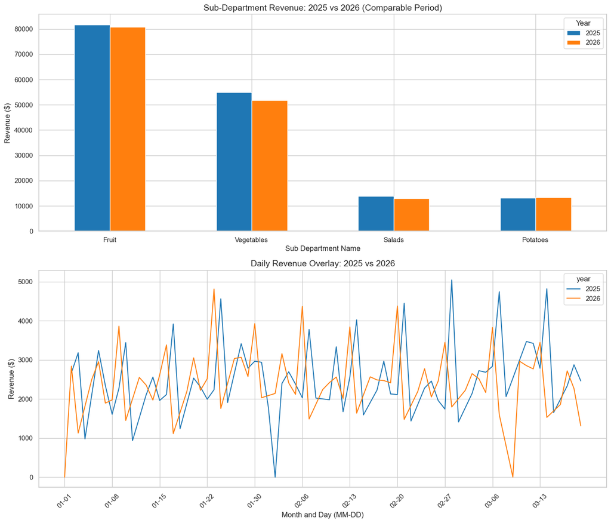

```python
dept_yoy = clean_sales.pivot_table(index="Sub Department Name", columns="year", values="Sales Ex GST", aggfunc="sum").fillna(0)
dept_yoy['Total'] = dept_yoy.sum(axis=1)
dept_yoy = dept_yoy.sort_values('Total', ascending=False).drop(columns='Total').head(15)

fig, (ax1, ax2) = plt.subplots(2, 1, figsize=(14, 12))

# Chart 1: Revenue by Dept
dept_yoy.plot(kind="bar", color=['#1f77b4', '#ff7f0e'], ax=ax1)
ax1.set_title(f"Sub-Department Revenue: 2025 vs 2026 (Comparable Period)", fontsize=14)
ax1.set_ylabel("Revenue ($)")
ax1.tick_params(axis='x', rotation=0)
ax1.legend(title="Year")

# Chart 2: Daily Overlay
daily_yoy = comparable_sales.groupby(['mm_dd', 'year'])['Sales Ex GST'].sum().reset_index()
sns.lineplot(data=daily_yoy, x='mm_dd', y='Sales Ex GST', hue='year', palette=['#1f77b4', '#ff7f0e'], linewidth=1.5, ax=ax2)
ax2.set_title("Daily Revenue Overlay: 2025 vs 2026", fontsize=14)
ax2.set_xlabel("Month and Day (MM-DD)")
ax2.set_ylabel("Revenue ($)")
ticks = ax2.get_xticks()
ax2.set_xticks(ticks[::7])
ax2.tick_params(axis='x', rotation=45)

plt.tight_layout()
plt.show()
```

## 3. Micro-Analysis: "Basket Builders" vs. "Profit Drivers"

**Summary:** Our volume relies heavily on a few staple items (Bananas, Carrots, Cucumbers) which drive frequent register scans (The Basket Builders). However, actual profit dollars are disproportionately generated by high-margin lines (The Profit Drivers). We must ensure staple items remain competitively priced to drive foot traffic while optimizing placement for high-margin items.

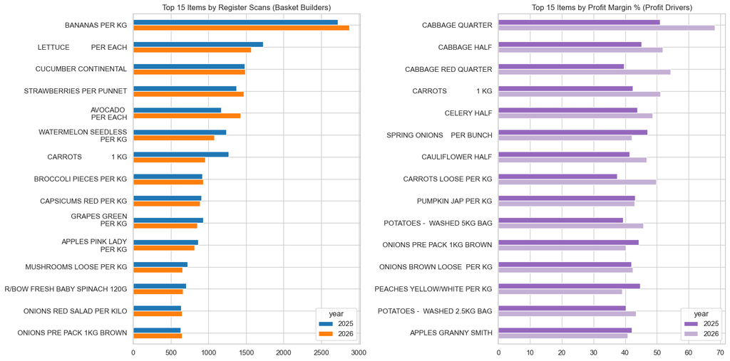

```python
# Top 15 by Scans (Lines) - Basket Builders
items_yoy = clean_sales.pivot_table(index="Name", columns="year", values="Lines", aggfunc="sum").fillna(0)
items_yoy['Total'] = items_yoy.sum(axis=1)
top_items = items_yoy.sort_values('Total', ascending=False).drop(columns='Total').head(15)

# Top 15 by GP Margin - Profit Drivers
item_margins = clean_sales.groupby(['Name', 'year']).agg(total_sales=('Sales Ex GST', 'sum'), total_gp=('GP $', 'sum')).reset_index()
valid_items = item_margins.groupby('Name')['total_sales'].sum()
valid_items = valid_items[valid_items > 500].index
item_margins = item_margins[item_margins['Name'].isin(valid_items)]
item_margins['Margin %'] = (item_margins['total_gp'] / item_margins['total_sales']) * 100
margin_yoy = item_margins.pivot(index="Name", columns="year", values="Margin %").fillna(0)
margin_yoy['Avg_Margin'] = margin_yoy.mean(axis=1)
top_margin_items = margin_yoy.sort_values('Avg_Margin', ascending=False).drop(columns='Avg_Margin').head(15)

fig, (ax1, ax2) = plt.subplots(1, 2, figsize=(16, 8))

# Plot Basket Builders
top_items.plot(kind="barh", color=['#1f77b4', '#ff7f0e'], ax=ax1)
ax1.set_title("Top 15 Items by Register Scans (Basket Builders)", fontsize=12)
ax1.set_ylabel("")
ax1.invert_yaxis()

# Plot Profit Drivers
top_margin_items.plot(kind="barh", color=['#9467bd', '#c5b0d5'], ax=ax2)
ax2.set_title("Top 15 Items by Profit Margin % (Profit Drivers)", fontsize=12)
ax2.set_ylabel("")
ax2.invert_yaxis()

plt.tight_layout()
plt.show()
```

## 4. Advanced Analytics: Pricing Strategy & Price Elasticity

**Summary:** We calculated the Volume-Weighted Average Price and mapped it against volume drops to find our **Price Elasticity of Demand (PED)**. The negative correlation indicates that recent price hikes actively suppressed customer volume on core items.

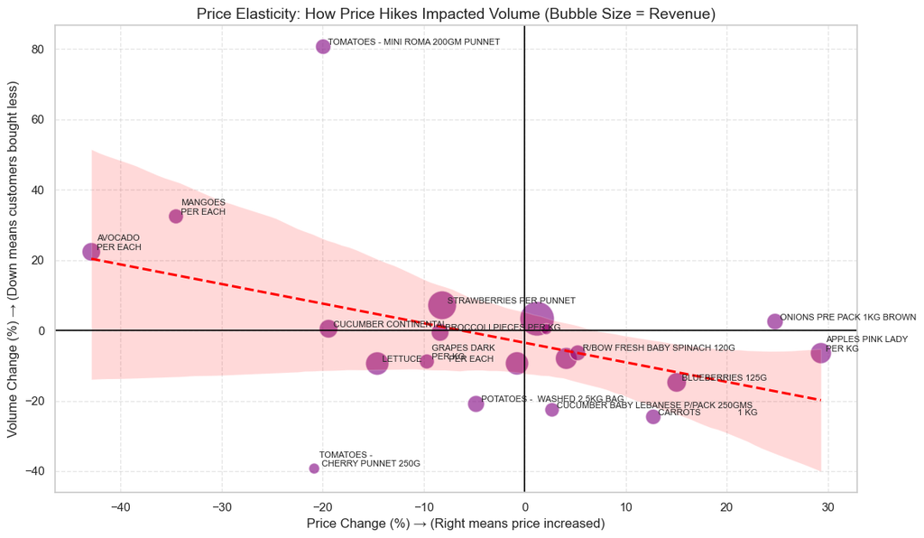

```python
# Safely filter out clearance items to avoid distorting base price elasticity
base_sales = clean_sales[
    (~clean_sales['Name'].str.contains('REDUCED|CLEARANCE|MARKDOWN', case=False, na=False)) &
    (clean_sales['Quantity'] > 0)
].copy()

top_20 = base_sales.groupby('Name')['Quantity'].sum().nlargest(20).index

# Calculate Volume and Weighted Average Price (Total Revenue / Total Quantity)
elasticity_data = base_sales[base_sales['Name'].isin(top_20)].groupby(['Name', 'year']).agg(
    total_sales=('Sales Ex GST', 'sum'),
    total_volume=('Quantity', 'sum')
)
elasticity_data['weighted_price'] = elasticity_data['total_sales'] / elasticity_data['total_volume']
elasticity_data = elasticity_data.unstack('year').dropna()

# Calculate % Changes
p_change = (elasticity_data[('weighted_price', 2026)] / elasticity_data[('weighted_price', 2025)] - 1) * 100
v_change = (elasticity_data[('total_volume', 2026)] / elasticity_data[('total_volume', 2025)] - 1) * 100

ped_df = pd.DataFrame({
    '2025 Price ($)': elasticity_data[('weighted_price', 2025)],
    '2026 Price ($)': elasticity_data[('weighted_price', 2026)],
    'Price Change (%)': p_change,
    'Volume Change (%)': v_change,
    'Total 2026 Revenue': elasticity_data[('total_sales', 2026)] # Used for bubble size
}).round(2)

ped_df['PED Score'] = np.where(ped_df['Price Change (%)'] != 0,
                               ped_df['Volume Change (%)'] / ped_df['Price Change (%)'], 0).round(2)

# Plot Bubble Chart
plt.figure(figsize=(12, 7))
sns.scatterplot(
    data=ped_df, x='Price Change (%)', y='Volume Change (%)',
    size='Total 2026 Revenue', sizes=(100, 1000), alpha=0.6, color='purple', legend=False
)
sns.regplot(data=ped_df, x='Price Change (%)', y='Volume Change (%)', scatter=False, color='red', line_kws={'linestyle':'--'})

for i, row in ped_df.iterrows():
    if abs(row['Price Change (%)']) > 5 or abs(row['Volume Change (%)']) > 10:
        plt.text(row['Price Change (%)'] + 0.5, row['Volume Change (%)'] + 0.5, i, fontsize=8)

plt.axhline(0, color='black', linewidth=1.2)
plt.axvline(0, color='black', linewidth=1.2)
plt.title("Price Elasticity: How Price Hikes Impacted Volume (Bubble Size = Revenue)", fontsize=14)
plt.xlabel("Price Change (%) → (Right means price increased)")
plt.ylabel("Volume Change (%) → (Down means customers bought less)")
plt.grid(True, linestyle='--', alpha=0.5)
plt.tight_layout()
plt.show()
```

## 5. Actionable Insights: The "Margin Trap" Hitlist

The table below identifies the "Margin Trap" culprits: products where we raised the price, customers bought less, and as a direct result, we made *less total profit dollars* than last year. Lowering the retail price of these specific items is the fastest way to win back volume and recover lost GP.

```python
# Find total GP lost per item
item_gp = base_sales.groupby(['Name', 'year'])['GP $'].sum().unstack('year').dropna()
item_gp['GP $ Difference'] = item_gp[2026] - item_gp[2025]
target_list = ped_df.join(item_gp[['GP $ Difference']])

# Filter for the Margin Trap: Price UP, Volume DOWN, GP $ DOWN
action_list = target_list[
    (target_list['Price Change (%)'] > 0) &
    (target_list['Volume Change (%)'] < 0) &
    (target_list['GP $ Difference'] < 0)
].copy().sort_values('GP $ Difference', ascending=True)

cols_to_display = ['2025 Price ($)', '2026 Price ($)', 'Price Change (%)', 'Volume Change (%)', 'GP $ Difference']
display(action_list[cols_to_display].round(2))

total_lost = action_list['GP $ Difference'].sum()
print(f"📉 Total Gross Profit bleeding across these {len(action_list)} items: ${abs(total_lost):,.2f}")
```

| Name | 2025 Price ($) | 2026 Price ($) | Price Change (%) | Volume Change (%) | GP $ Difference |
| --- | --- | --- | --- | --- | --- |
| GRAPES GREEN\nPER KG\n | 5.99 | 6.24 | 4.10 | -7.96 | -115.35 |
| CUCUMBER BABY LEBANESE P/PACK 250GMS | 3.79 | 3.89 | 2.69 | -22.57 | -36.12 |

```
📉 Total Gross Profit bleeding across these 2 items: $151.47
```

### 💡 Final Strategic Recommendations:

1. **Implement Targeted Price Rollbacks:** Immediately review pricing on Green Grapes and Baby Lebanese Cucumbers (the top items on the Margin Trap list). A slight price rollback toward 2025 levels is recommended to stimulate volume and recover profit.
2. **Review Cashier Checkout Procedures:** In Q1 2025, significant revenue was processed through a generic "FRUIT AND VEG / Open Ring" button, masking vital inventory data and skewing margin metrics. Ensure cashiers are trained to look up exact PLU codes to maintain data integrity.

# 6. Core Inventory & Operations Analysis

In this phase, we transition from basic data cleaning into strategic business intelligence. We will tackle two critical operational questions: determining our most valuable products to optimize shelf space, and understanding the weekly rhythm of the store to optimize staffing and fresh produce ordering.

## 6.1 YoY ABC Classification & Portfolio Migration

**Business Objective:** A static 80/20 rule only tells us what is happening *now*. To be proactive, we must analyze the **migration** of our portfolio. Did items that were "vital" (Class A) in 2025 maintain their status in 2026? Identifying products that are falling out of the A-tier gives buyers early warning signs to reduce shelf space before dead stock accumulates.

```python
# 1. Calculate item revenue per year within the comparable period
item_yoy_sales = clean_sales.groupby(['Name', 'year'])['Sales Ex GST'].sum().unstack('year').fillna(0)

# 2. Function to assign ABC classes based on Pareto distribution
def calculate_abc(series):
    # Sort descending and calculate cumulative %
    sorted_series = series.sort_values(ascending=False)
    cum_pct = (sorted_series.cumsum() / sorted_series.sum()) * 100

    # Define conditions and choices. Default is 'C' to fix NumPy dtype matching.
    conditions = [cum_pct <= 80, cum_pct <= 95]
    choices = ['A', 'B']
    return pd.Series(np.select(conditions, choices, default='C'), index=sorted_series.index)

# Apply ABC classification for both years independently
abc_2025 = calculate_abc(item_yoy_sales[2025]).rename('Class_2025')
abc_2026 = calculate_abc(item_yoy_sales[2026]).rename('Class_2026')

# 3. Merge classes and calculate revenue shifts
abc_migration = pd.concat([item_yoy_sales, abc_2025, abc_2026], axis=1)
abc_migration['Revenue Shift ($)'] = abc_migration[2026] - abc_migration[2025]

# Identify the "Fallen Stars" (Dropped out of Class A) and "Rising Stars" (Promoted to Class A)
fallen_stars = abc_migration[(abc_migration['Class_2025'] == 'A') & (abc_migration['Class_2026'] != 'A')]
rising_stars = abc_migration[(abc_migration['Class_2025'] != 'A') & (abc_migration['Class_2026'] == 'A')]
```

## --- VISUALIZATION: PARETO 2026 WITH MIGRATION HIGHLIGHTS ---

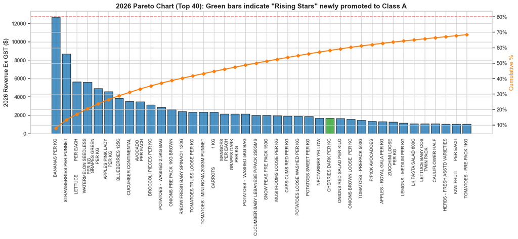

```
--- Fallen Stars (Former A-Class items that lost status in 2026) ---
```

| Name | 2025 | 2026 | Class_2025 | Class_2026 | Revenue Shift ($) |
| --- | --- | --- | --- | --- | --- |
| COMM CO SALAD KIT ASIAN 250GM | 1092.59 | 0.00 | A | C | -1092.59 |
| GRAPES BLACK SEEDLESS PER KG | 1622.34 | 532.43 | A | B | -1089.91 |
| PEAR GREEN PER KG | 1096.28 | 552.74 | A | B | -543.54 |
| COMM CO KALESLAW KIT 400GM | 893.00 | 518.05 | A | B | -374.95 |
| SWEET CORN PRE PACK 500GMS | 872.54 | 670.86 | A | B | -201.68 |

```python
from matplotlib.ticker import PercentFormatter

# Sort 2026 for the Pareto curve
pareto_df = abc_migration.sort_values(2026, ascending=False).head(40)
pareto_df['Cum_Pct_26'] = (pareto_df[2026].cumsum() / abc_migration[2026].sum()) * 100

fig, ax1 = plt.subplots(figsize=(15, 7))

# Base Bar Chart (2026 Revenue)
bars = ax1.bar(pareto_df.index, pareto_df[2026], color='#1f77b4', alpha=0.8, edgecolor='black')

# Highlight Rising Stars in Green
for i, item in enumerate(pareto_df.index):
    if item in rising_stars.index:
        bars[i].set_color('#2ca02c') # Green for newly promoted A-class
        bars[i].set_edgecolor('black')

ax1.set_ylabel('2026 Revenue Ex GST ($)', color='black', fontsize=12)
ax1.set_xticks(range(len(pareto_df)))
ax1.set_xticklabels(pareto_df.index, rotation=90, fontsize=9)

# Line Chart (Cumulative %)
ax2 = ax1.twinx()
ax2.plot(pareto_df.index, pareto_df['Cum_Pct_26'], color='#ff7f0e', marker='D', ms=5, linewidth=2)
ax2.yaxis.set_major_formatter(PercentFormatter())
ax2.set_ylabel('Cumulative %', color='#ff7f0e', fontsize=12)
ax2.axhline(80, color='red', linestyle='--', alpha=0.6, label='80% Threshold')

plt.title('2026 Pareto Chart (Top 40): Green bars indicate "Rising Stars" newly promoted to Class A', fontsize=14, fontweight='bold')
plt.tight_layout()
plt.show()

print("--- Fallen Stars (Former A-Class items that lost status in 2026) ---")
display(fallen_stars[[2025, 2026, 'Class_2025', 'Class_2026', 'Revenue Shift ($)']].sort_values('Revenue Shift ($)'))
```

## 6.2 Day-of-Week Behavioral Shifts & Heatmap

**Business Objective:** Did the store's weekly rhythm change YoY? If customers are shifting their fresh produce shopping from Sundays to mid-week, ordering schedules from the warehouse must pivot instantly. We will look at the YoY variance in average daily sales by department to expose changing consumer habits.

```python
# 1. Extract Time Data
clean_sales['DayOfWeek'] = clean_sales['Date'].dt.day_name()
days_order = ['Monday', 'Tuesday', 'Wednesday', 'Thursday', 'Friday', 'Saturday', 'Sunday']

# 2. Calculate the AVERAGE daily revenue for each Day of the Week, split by Year
# First, aggregate absolute daily totals to avoid skewed means
daily_dept_sales = clean_sales.groupby(['Date', 'DayOfWeek', 'Sub Department Name', 'year'])['Sales Ex GST'].sum().reset_index()

# Now find the mean revenue for those days
avg_dow = daily_dept_sales.groupby(['year', 'Sub Department Name', 'DayOfWeek'])['Sales Ex GST'].mean().unstack(['year']).fillna(0)

# Calculate YoY % Variance by Day and Category
# Wrap in pd.Series using the exact MultiIndex from avg_dow
variance_values = np.where(avg_dow[2025] > 0, ((avg_dow[2026] / avg_dow[2025]) - 1) * 100, 0)
dow_variance_pct = pd.Series(variance_values, index=avg_dow.index)

# 3. Pivot for Heatmaps
heatmap_2026 = avg_dow[2026].unstack('DayOfWeek').reindex(columns=days_order).fillna(0)
heatmap_variance = dow_variance_pct.unstack('DayOfWeek').reindex(columns=days_order).fillna(0)

# Filter out very small departments that create noisy variance percentages
valid_depts = heatmap_2026.sum(axis=1)[heatmap_2026.sum(axis=1) > 1000].index
heatmap_2026 = heatmap_2026.loc[valid_depts]
heatmap_variance = heatmap_variance.loc[valid_depts]
```

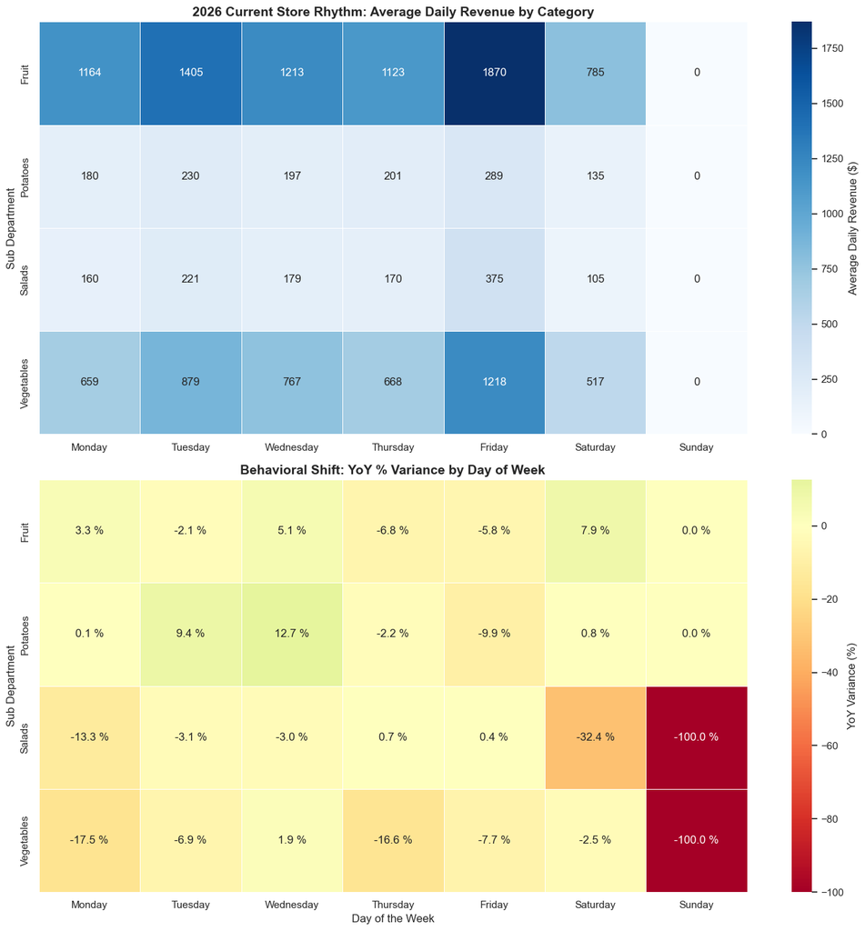

```python
fig, (ax1, ax2) = plt.subplots(2, 1, figsize=(14, 14))

# Chart 1: The current state (2026 Rhythm)
sns.heatmap(
    heatmap_2026, annot=True, fmt=".0f", cmap="Blues",
    linewidths=.5, ax=ax1, cbar_kws={'label': 'Average Daily Revenue ($)'}
)
ax1.set_title("2026 Current Store Rhythm: Average Daily Revenue by Category", fontsize=14, fontweight='bold')
ax1.set_xlabel("")
ax1.set_ylabel("Sub Department")

# Chart 2: The Shift (YoY Variance)
# Using a diverging colormap: Red = dropped YoY, Green = Grew YoY
sns.heatmap(
    heatmap_variance, annot=True, fmt=".1f", cmap="RdYlGn", center=0,
    linewidths=.5, ax=ax2, cbar_kws={'label': 'YoY Variance (%)'}
)
ax2.set_title("Behavioral Shift: YoY % Variance by Day of Week", fontsize=14, fontweight='bold')
ax2.set_xlabel("Day of the Week", fontsize=12)
ax2.set_ylabel("Sub Department")

# Format annotations in the variance heatmap to show % symbol
for t in ax2.texts: t.set_text(t.get_text() + " %")

plt.tight_layout()
plt.show()
```